# Tratamiento de datos y QC

Transcriptómica HTG

Aarón Marcén

2024-03-22

# Importación y Curación de Datos

Se importan los dos archivos excel generados a partir de la base de datos original llamada `HTG_Parsed_database_07.03.2024`. El primero llamado `htg_db` contiene la matriz de counts obtenida a partir de la transcriptómica realizada con la tecnología HTG. El segundo llamado `htg_meta` contiene los metadatos de las muestras del estudio.

El dataframe `htg_db` está compuesto por 19620 filas, entre las cuales contiene 4 campos (4 primeras filas) con datos identificadores, que indican la fecha en la que se realizó la transcriptómica o que reflejan el número total de counts cuantificados para cada muestra. Y 61 columnas, que hacen referencia a las 61 muestras del estudio.

A partir de `htg_db` se extrae el dataframe `cts` que únicamente contiene la matriz de counts, con las 19616 sondas cuantificadas como filas y las 61 muestras analizadas como columnas.

La matriz de metadatos contiene diferentes campos que informan sobre el origen de las muestras y los pacientes a los que pertenecen, como: el identificador de muestra, el contenido porcentual de células tumorales, la localización del tumor, el diagnóstico del paciente, el grupo experimental al cual ha sido asignado, entre otros.

Se verifica que las mismas muestras están descritas como columnas de la matriz de counts y como filas en la matriz de metadatos. Pero se confirma que no se encuentran en el mismo orden. Por tanto, se procede a reordenar las filas de `htg_meta` para que sigan el orden de las columnas de `htg_db`.

A continuación se muestran las primeras filas de los dataframes `htg_db` y `htg_meta` respectivamente.

| 4-B00-15661-B | 4-B04-23636-B | 4-B05-15288-B | 4-B06-00420 | 4-B16-11432 |
| --- | --- | --- | --- | --- |
| 1 | 2 | 3 | 4 | 5 |
| A1 | B1 | C1 | D1 | E1 |
| 16/02/2023 | 16/02/2023 | 16/02/2023 | 16/02/2023 | 16/02/2023 |
| 9650628 | 33950226 | 24680689 | 10605963 | 7395173 |
| 19 | 24 | 261 | 201 | 14 |
| 0 | 0 | 439 | 0 | 2 |
| 1472 | 2417 | 4409 | 1990 | 658 |
| 0 | 110 | 0 | 46 | 0 |
| 0 | 0 | 0 | 0 | 0 |
| 95 | 181 | 1272 | 0 | 45 |

| id | tumor cell content | site | Dx | Group |
| --- | --- | --- | --- | --- |
| 4-B00-15661-B | 70 | lymph node | DLBCL | DLBCL with CNS inv |
| 4-B04-23636-B | 70 | brain | DLBCL | SCNSL |
| 4-B05-15288-B | 70 | rinopharynx | DLBCL | DLBCL with CNS inv |

Una vez curada la matriz de counts `cts`, se procede a realizar dos subsets de esta matriz. El primero llamado `cts_gens` que contiene las filas de la matriz correspondientes a los 19398 genes cuantificados. Y el segundo subset llamado `cts_ctrls` que contiene las filas de la matriz correspondientes a los 218 controles utilizados por la casa comercial de la plataforma HTG para generar el control de calidad de las muestras.

Finalmente se procede a compilar los nombres repetidos con distintos formatos, en la columna `site` de la matriz de metadatos. Esta columna informa del lugar de obtención de la biopsia. Se muestran dos tablas de frecuencias en función de la variable `site`, antes y después de la compilación.

```
##
##                 BMO               brain               Brain      brain (vermix)
##                   2                  30                   1                   1
##              clivus            etmoides                  LN              lumbar
##                   2                   1                   5                   2
##          lymph node         MEDIASTINUM          MESENTERIC           PARARENAL
##                   5                   1                   1                   1
##                PIEL              retina         rinopharynx                skin
##                   1                   1                   1                   1
##          skin skull   skin/subcutaneous soft tissue (thigh)   VALVULA ILEOCECAL
##                   1                   1                   1                   1
##              vitreo
##                   1
```

```
##
##                 BMO               brain      brain (vermix)              clivus
##                   2                  31                   1                   2
##            etmoides              lumbar          lymph node         MEDIASTINUM
##                   1                   2                  10                   1
##          MESENTERIC           PARARENAL              retina         rinopharynx
##                   1                   1                   1                   1
##                skin          skin skull   skin/subcutaneous soft tissue (thigh)
##                   2                   1                   1                   1
##   VALVULA ILEOCECAL              vitreo
##                   1                   1
```

```r
# Se almacenan los nombres de fila
rownames_meta <- rownames(htg_meta)
# Nueva variable tissue_group que simplifica site mediante agrupación
htg_meta <- htg_meta %>%
  mutate(tissue_group = case_when(
    site %in% c("lymph node") ~ "lymph node",
    site %in% c("BMO") ~ "BMO",
    site %in% c("clivus", "etmoides") ~ "bone",
    site %in% c("brain", "brain (vermix)", "vitreo", "retina") ~ "CNS",
    site %in% c("MEDIASTINUM", "MESENTERIC", "lumbar", "PARARENAL", "soft tissue (thigh)", "skin", "skin skull", "skin/subcutaneous") ~ "soft tissue/skin",
    site %in% c("VALVULA ILEOCECAL", "rinopharynx") ~ "mucosa",
    TRUE ~ NA_character_  # Agregar un valor por defecto en caso de que no haya coincidencia
  ))

# Recuperar los nombres de fila correspondientes a las muestras
rownames(htg_meta) <- rownames_meta
```

# Estadística Descriptiva

Para entender el conjunto de datos, se procede a describir la matriz metadatos para entender mejor el contexto de las muestras.

```r
# Número de muestras por grupo experimental
table(htg_meta$Group)
```

```
##
##        DLBCL with CNS inv          DLBCL wo CNS inv                     PCNSL
##                        12                        13                        22
## REACTIVE BRAIN INFILTRATE                     SCNSL
##                         8                         6
```

```r
# Número de muestras por localización/tejido de la muestra
table(htg_meta$site)
```

```
##
##                 BMO               brain      brain (vermix)              clivus
##                   2                  31                   1                   2
##            etmoides              lumbar          lymph node         MEDIASTINUM
##                   1                   2                  10                   1
##          MESENTERIC           PARARENAL              retina         rinopharynx
##                   1                   1                   1                   1
##                skin          skin skull   skin/subcutaneous soft tissue (thigh)
##                   2                   1                   1                   1
##   VALVULA ILEOCECAL              vitreo
##                   1                   1
```

```r
table(htg_meta$tissue_group)
```

```
##
##              BMO             bone              CNS       lymph node
##                2                3               34               10
##           mucosa soft tissue/skin
##                2               10
```

[output not shown]

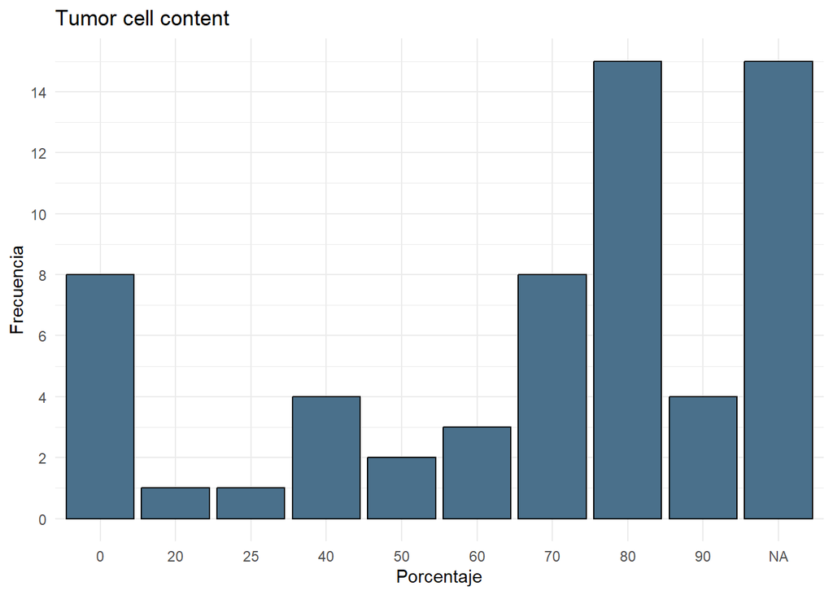

```r
# Número de historia clínica (NHC) de pacientes con más de una muestra
t_NHC <- table(htg_meta$NHC)
t_NHC_ap <- t_NHC[t_NHC>1]
t_NHC_ap
```

# Análisis de la variabilidad

Para iniciar el análisis de los datos, se procede a realizar un análisis de componentes principales (PCA). PCA es un análisis de reducción de la dimensionalidad que transforma un gran conjunto de variables correlacionadas en un nuevo conjunto de pocas variables no correlacionadas, llamadas componentes principales. Estas componentes principales son combinaciones lineales de las variables originales y están ordenadas por la cantidad de variabilidad original que capturan.

A continuación se muestran tres apartados gráficos que representan como se distribuyen las muestras en función de las primeras componentes principales (PCA). En ellos se remarcan y etiquetan las muestras más alejadas del centro promedio de los datos, es decir, las muestras que más difieren del conjunto. El primer apartado está realizado con el total de counts de cada muestra, el segundo con los counts de los genes y el tercero con los counts de los controles.

## PCA de las muestras (counts totales)

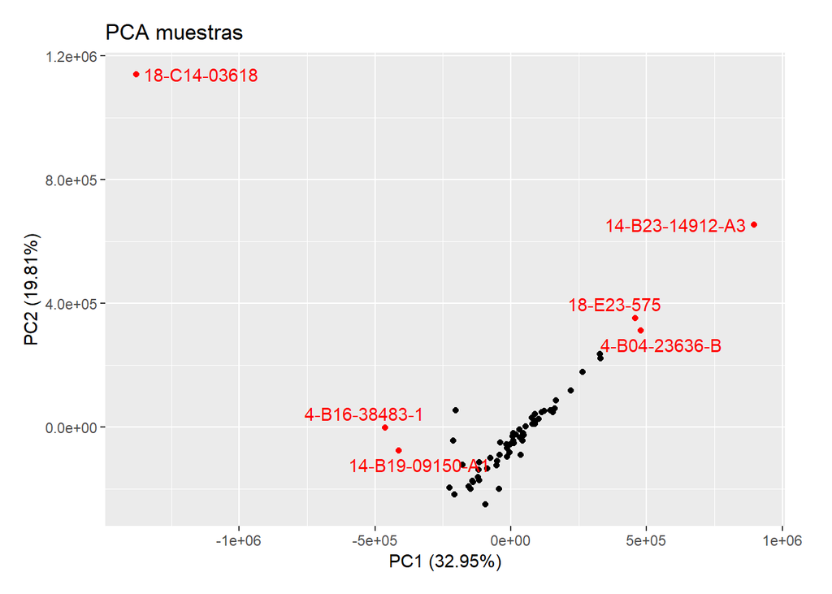

En el gráfico del PCA se puede observar la similitud entre las muestras del estudio. Comparando la distribución de las muestras entre las dos primeras componentes principales. La suma de ambas recoge aproximadamente la mitad de la variabilidad de las muestras. Se puede ver que el grueso de las muestras se distribuye formando una diagonal ascendente, lo que indica que existe una correlación positiva entre las dos componentes principales. Se remarcan en rojo las muestras más dispares respecto al promedio del conjunto.

A continuación se muestran los datos de las muestras etiquetadas (con menos similitud del conjunto):

| id | tumor cell content | site | Dx | Group |
| --- | --- | --- | --- | --- |
| 18-C14-03618 | NA | vitreo | DLBCL | SCNSL |
| 14-B23-14912-A3 | 80 | brain | DLBCL | PCNSL |
| 18-E23-575 | NA | skin | DLBCL, NOS GCB-type | DLBCL wo CNS inv |
| 4-B04-23636-B | 70 | brain | DLBCL | SCNSL |
| 4-B16-38483-1 | 40 | BMO | DLBCL CD5+ | DLBCL with CNS inv |
| 14-B19-09150-A1 | NA | BMO | DLBCL | DLBCL wo CNS inv |

Dado que con las dos primeras componentes principales, se explica la mitad de la variabilidad observada en los datos crudos; se representa a continuación, la variabilidad o varianza explicada por las 10 primeras componentes. Esto se representa mediante una gráfica de barras en la que se indica la varianza acumulada como etiqueta encima de cada barra y mediante una gráfica en la que se muestra la varianza acumulada respecto a cada componente principal.

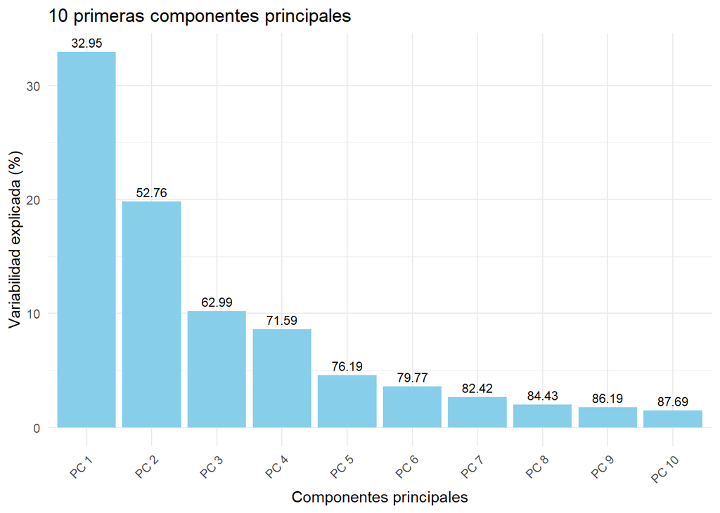

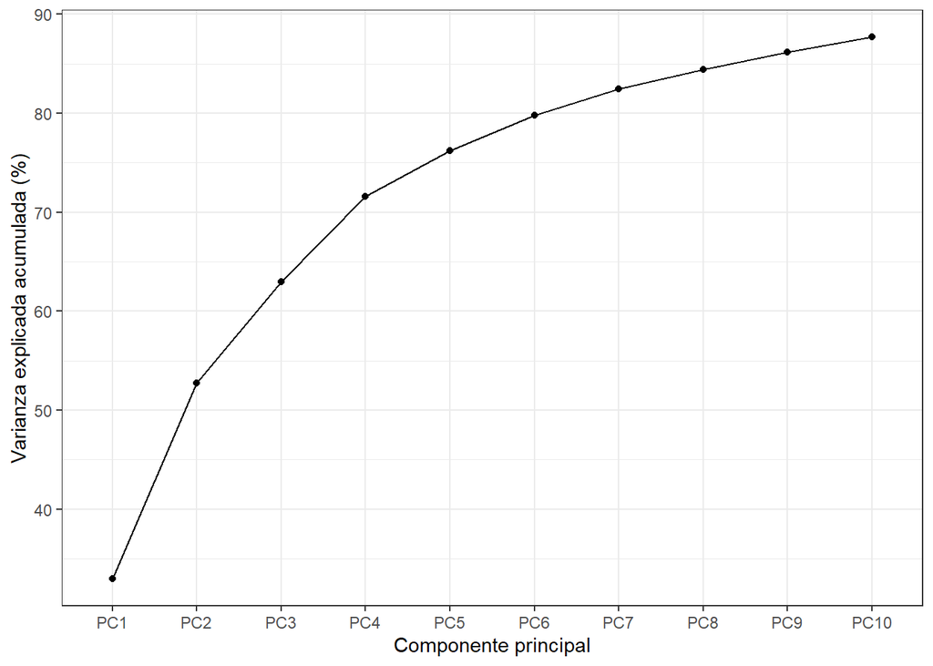

## PCA de las muestras (counts de genes)

En este apartado se repetirán las representaciones anteriores, pero esta vez, se analizarán únicamente, los counts de los genes de interés, excluyendo del análisis los counts pertenecientes a los controles.

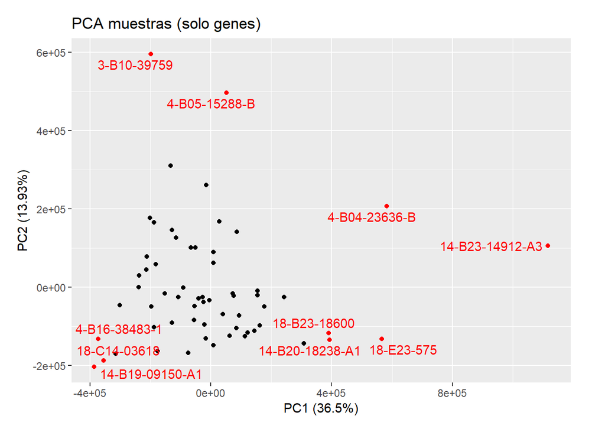

| id | tumor cell content | site | Dx | Group |
| --- | --- | --- | --- | --- |
| 14-B23-14912-A3 | 80 | brain | DLBCL | PCNSL |
| 3-B10-39759 | 70 | clivus | DLBCL | PCNSL |
| 4-B04-23636-B | 70 | brain | DLBCL | SCNSL |
| 18-E23-575 | NA | skin | DLBCL, NOS GCB-type | DLBCL wo CNS inv |
| 4-B05-15288-B | 70 | rinopharynx | DLBCL | DLBCL with CNS inv |
| 14-B19-09150-A1 | NA | BMO | DLBCL | DLBCL wo CNS inv |
| 14-B20-18238-A1 | 90 | lumbar | HGBCL | DLBCL with CNS inv |
| 18-B23-18600 | NA | brain | DLBCL TRANSFORMAT DE WM | SCNSL |
| 18-C14-03618 | NA | vitreo | DLBCL | SCNSL |
| 4-B16-38483-1 | 40 | BMO | DLBCL CD5+ | DLBCL with CNS inv |

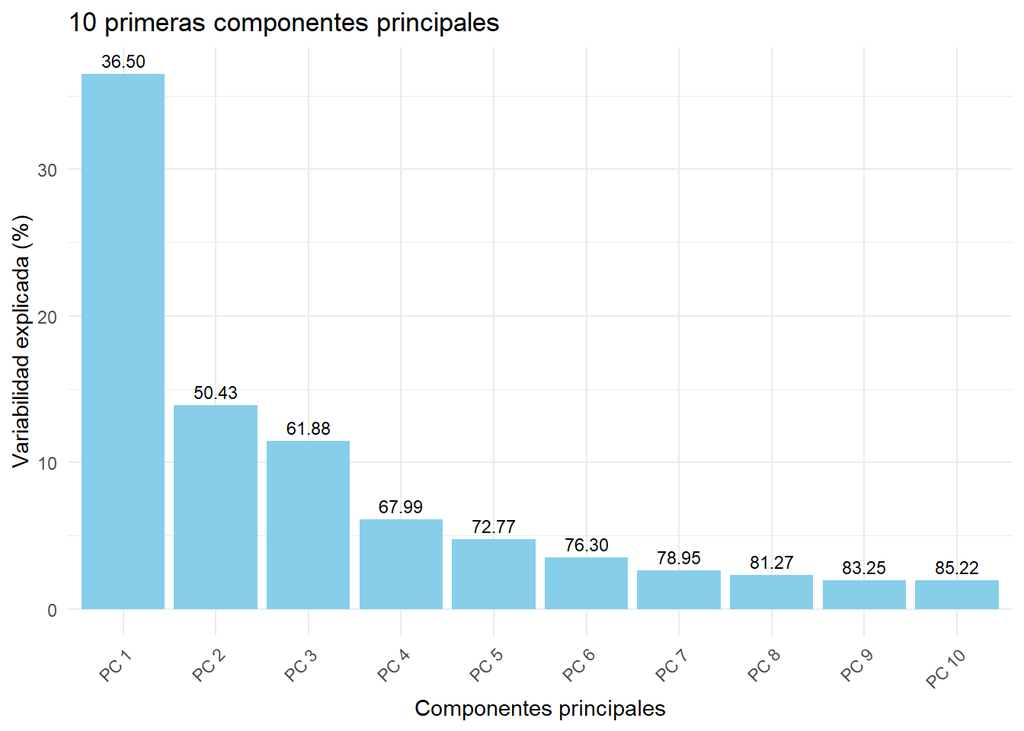

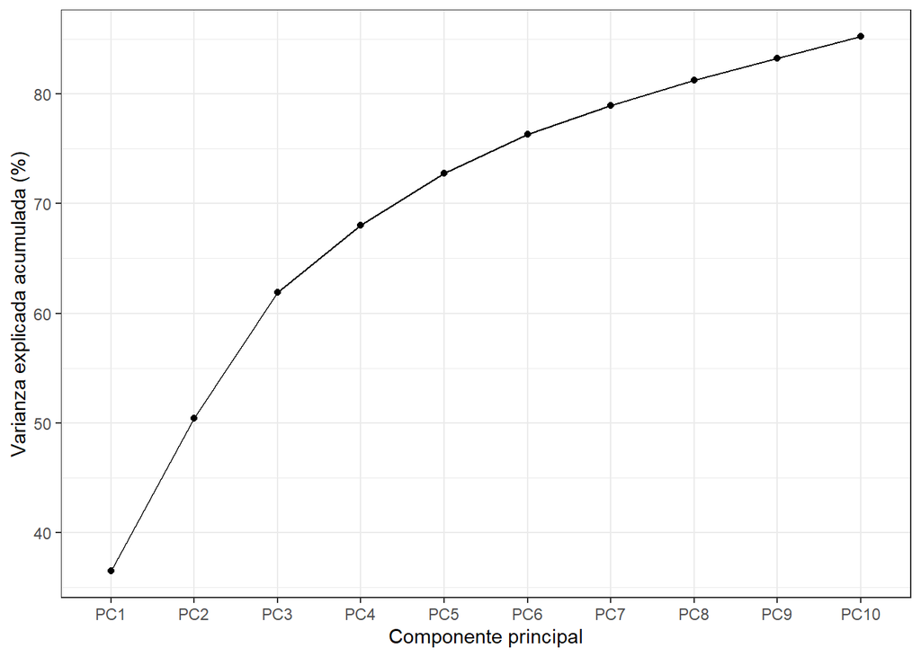

A continuación se muestran gráficos PCA comparando las primeras componentes principales y con las muestras clasificadas por grupos experimentales, para ver la variabilidad entre grupos e intra-grupo.

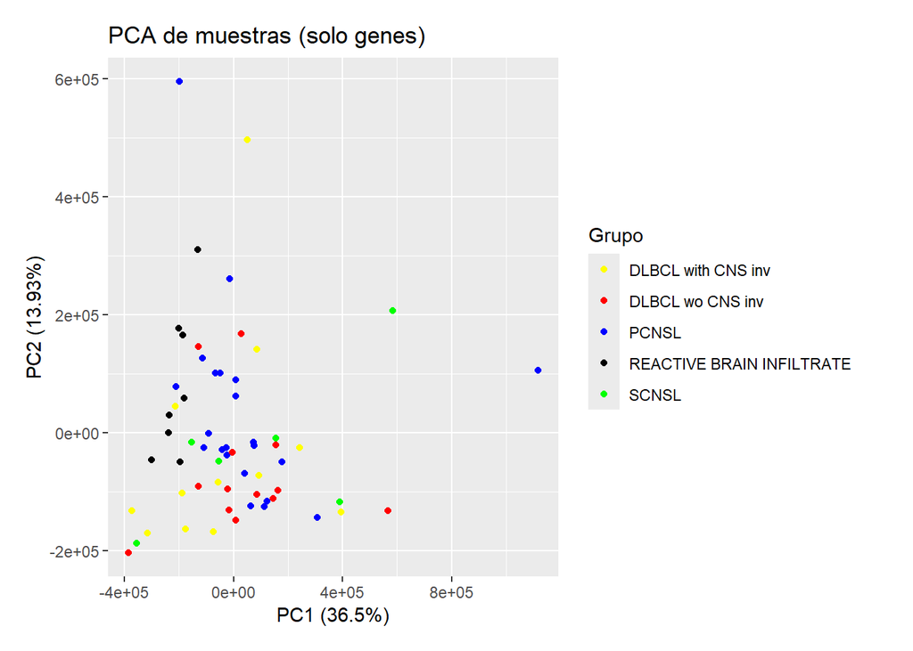

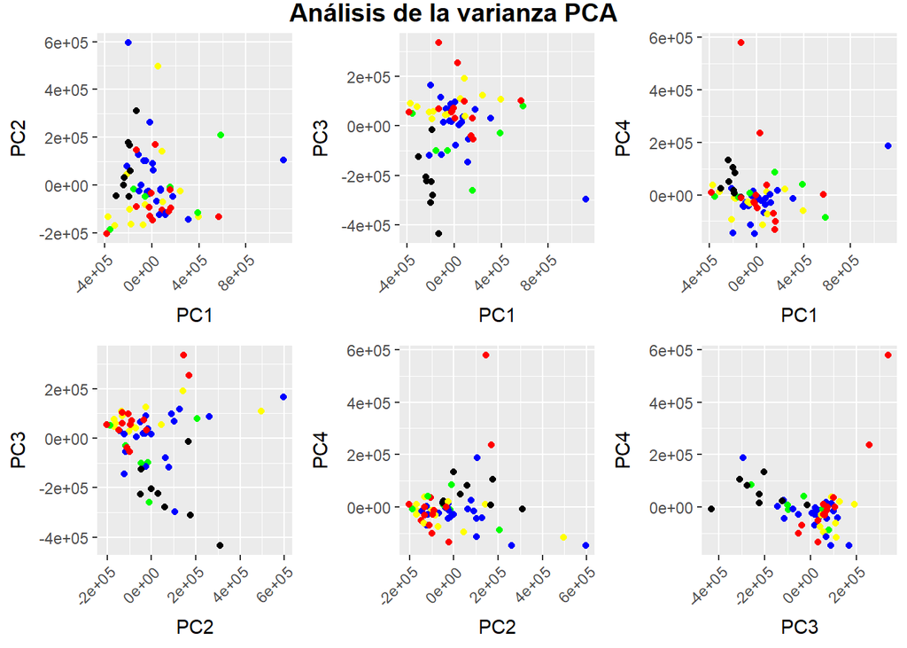

## PCA de las muestras (counts de controles)

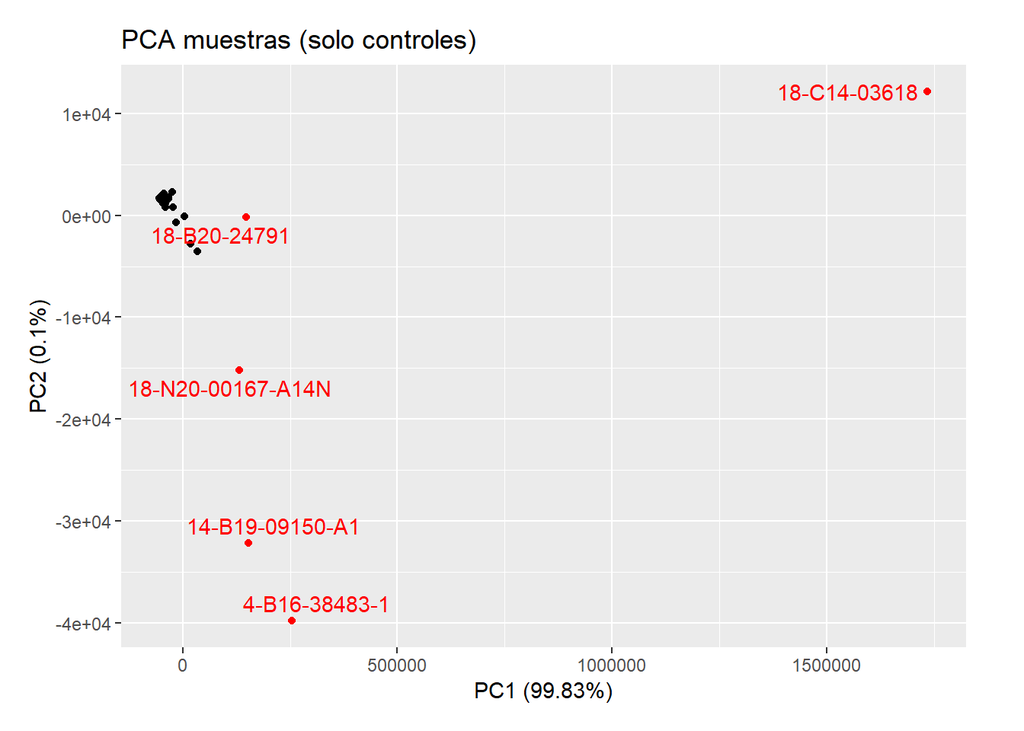

| id | tumor cell content | site | Dx | Group |
| --- | --- | --- | --- | --- |
| 18-C14-03618 | NA | vitreo | DLBCL | SCNSL |
| 4-B16-38483-1 | 40 | BMO | DLBCL CD5+ | DLBCL with CNS inv |
| 14-B19-09150-A1 | NA | BMO | DLBCL | DLBCL wo CNS inv |
| 18-B20-24791 | NA | VALVULA ILEOCECAL | DLBCL, NOS GCB-type | DLBCL wo CNS inv |
| 18-N20-00167-A14N | 0 | brain | ?? | REACTIVE BRAIN INFILTRATE |

# CONTROL DE CALIDAD

Debido a que el software original de la empresa HTG EdgeSeq ya no está disponible, parte de las muestras no han sido analizadas por dicho software, que realizaba un control de calidad, en base a los counts de diferentes controles negativos y positivos.

Dado que disponemos de los counts de estos controles y algunas muestras que fueron sometidas al QC, se procede a realizar un PCA de las muestras en base a los counts de los controles para comparar las muestras con “green flag” (muestras que pasaron y que no pasaron el QC del software comercial) respecto a las que no han sido analizadas.

## PCA de las muestras (solo controles)

[figure not shown]

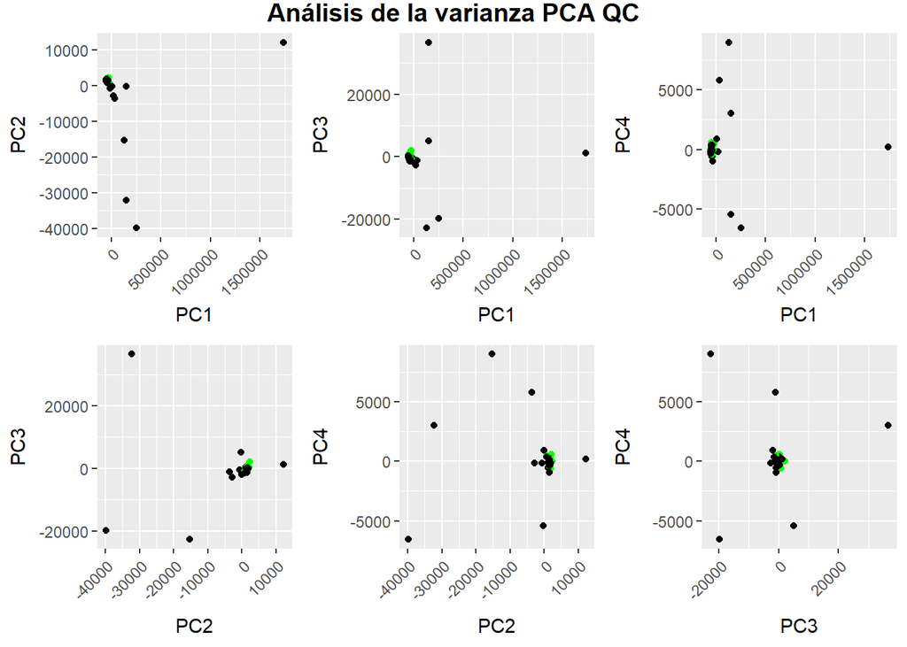

## Boxplots de genes y controles

Se representa la distribución de counts totales por muestras, en formato boxplot con escala logarítmica. Se muestran boxplots que representan los counts para los genes de las muestras y para los cuatro tipos de controles: de ARN externo o ERCC (external RNA Controls Consortium), Positivos, de contenido de ADN genómico (GDNA) y Negativos.

En ellos se remarcan en rojo, las muestras que no pasaron el QC del software asociado a la plataforma de transcriptómica masiva HTG-seq (HTG Molecular). En verde, los que si pasaron el QC (green flag) y en blanco, los que no se sometieron a dicho QC.

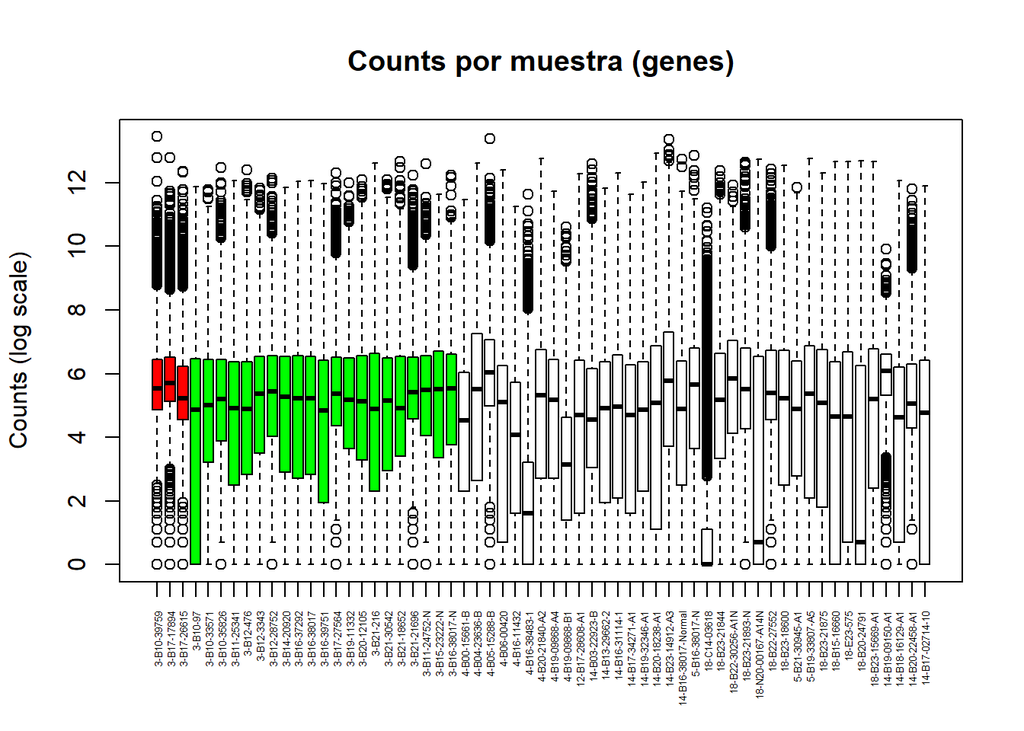

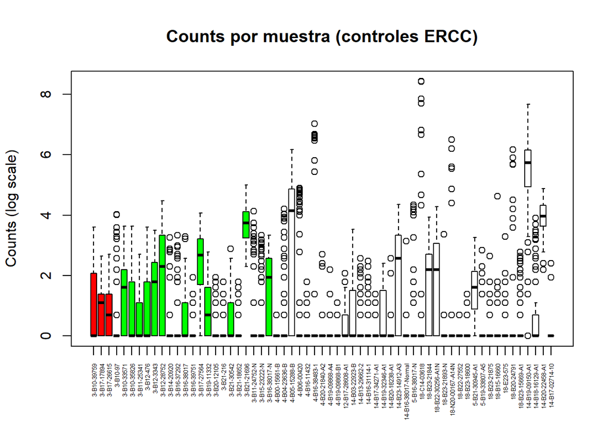

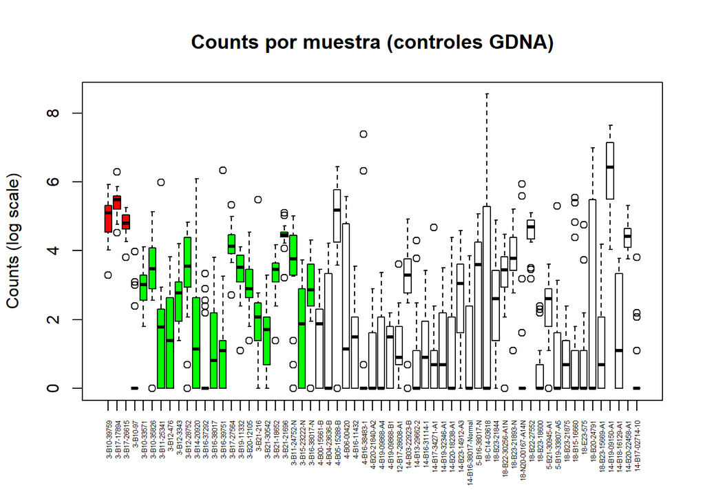

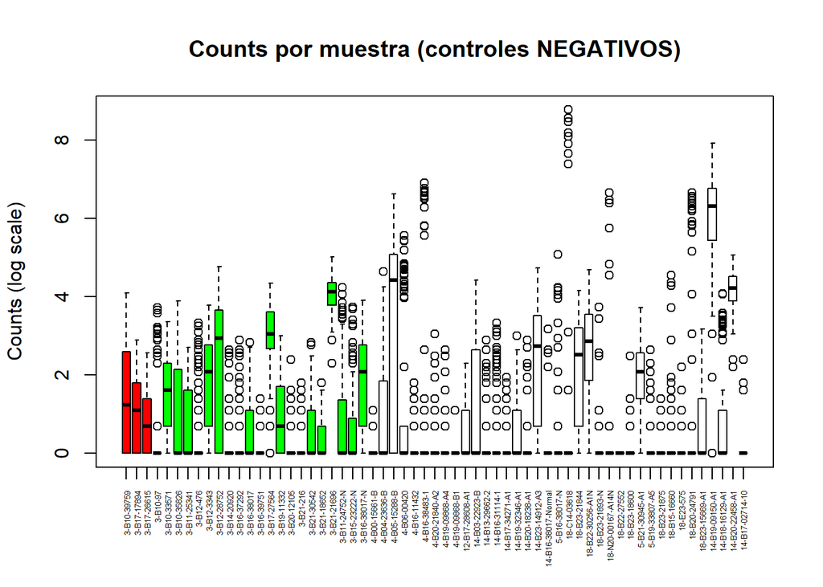

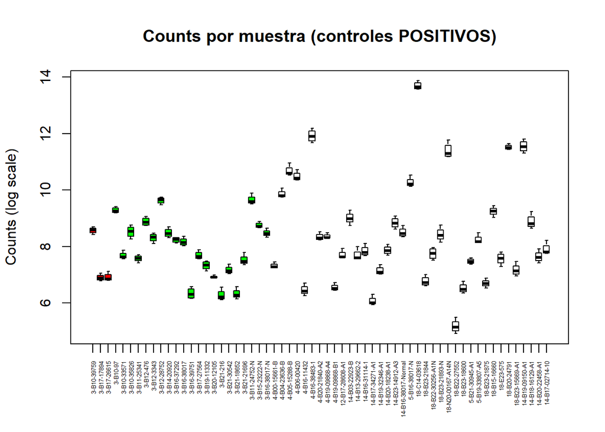

## Barplots de tamaño de librería y mediana de counts por muestra

A continuación se muestra un gráfico que representa el tamaño de librería (counts del total de genes) por muestra y la mediana de counts por muestra:

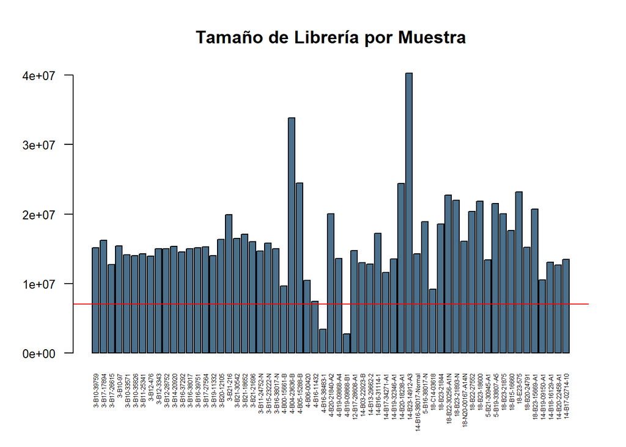

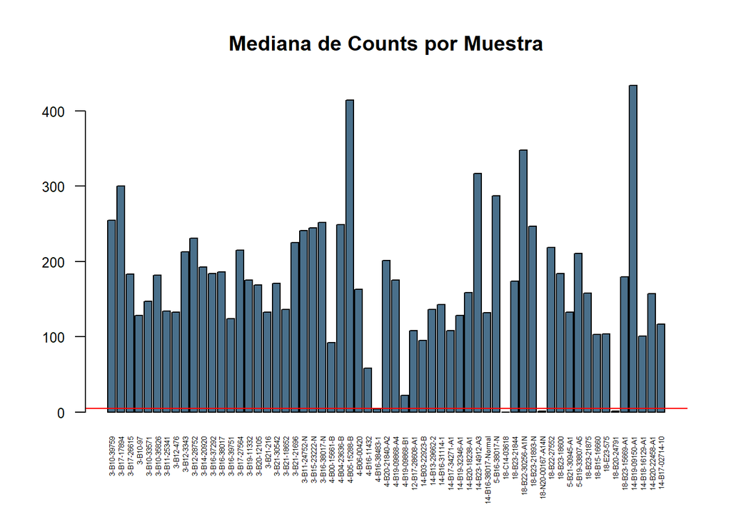

## Boxplots de criterios de aceptación del QC

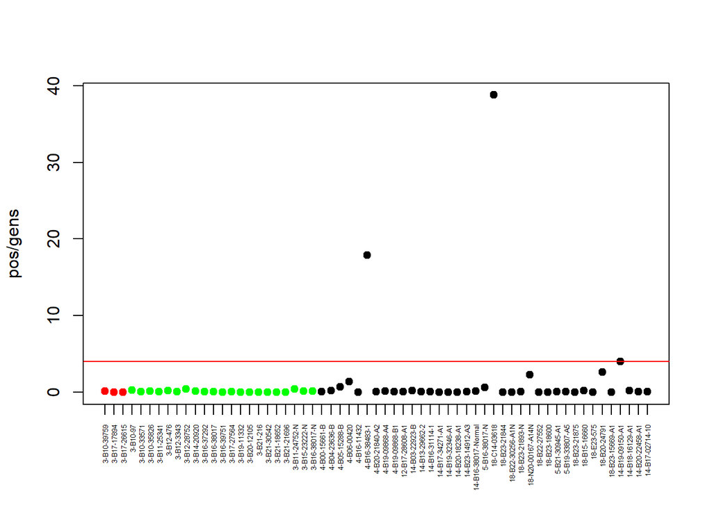

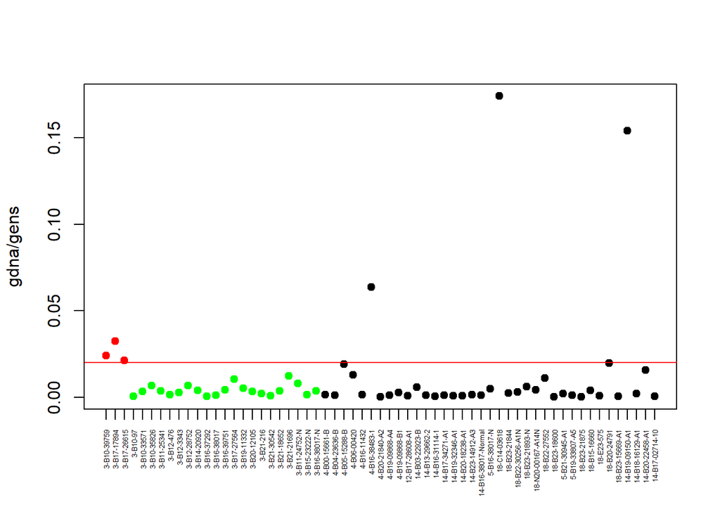

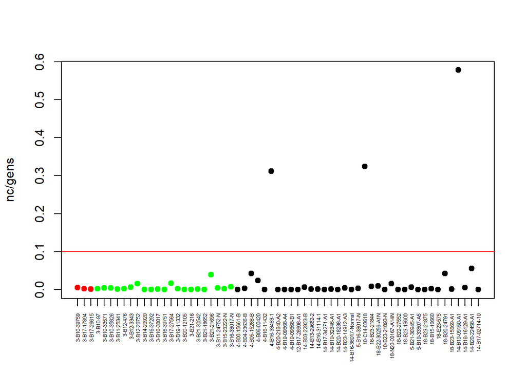

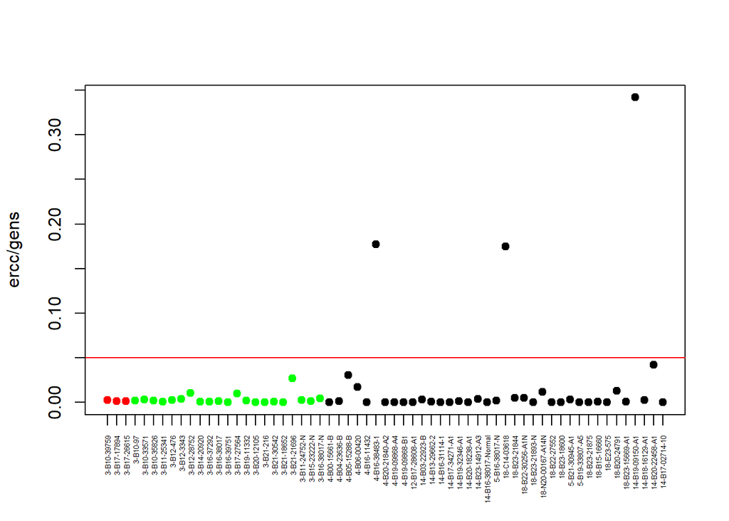

## Muestras Excluídas

| tumor cell content | site | Dx | Group | NHC | BX ASOCIADA | INCLUDE | Green flag | COMMENTS | tissue_group |
| --- | --- | --- | --- | --- | --- | --- | --- | --- | --- |
| 80 | brain | DLBCL | PCNSL | 205803 | NO | yes | no | NA | CNS |
| 90 | brain | DLBCL | PCNSL | 354123 | NO | yes | no | NA | CNS |
| 70 | clivus | DLBCL | PCNSL | 4597381 | NO | yes | no | Afectació de paret costal poc després. Potser no és un PCNSL | bone |
| NA | vitreo | DLBCL | SCNSL | 70001643 | B13-29662 | yes | NA | NA | CNS |
| 40 | BMO | DLBCL CD5+ | DLBCL with CNS inv | 5034247 | B20-21840 | yes | NA | NA | BMO |
| NA | BMO | DLBCL | DLBCL wo CNS inv | 5179312 | NO | yes | NA | NA | BMO |
| 80 | lymph node | FL 3A | DLBCL with CNS inv | 5221071 | B19-09868-A | yes | NA | NA | lymph node |
| NA | VALVULA ILEOCECAL | DLBCL, NOS GCB-type | DLBCL wo CNS inv | 5356770 | NO | yes | NA | NA | mucosa |
| 0 | brain | ?? | REACTIVE BRAIN INFILTRATE | 5332636 | NA | yes | NA | NA | CNS |

# Heatmap

Para finalizar este informe, se compila la información del control de calidad con anotaciones de metadatos, para comprender el conjunto de muestras.

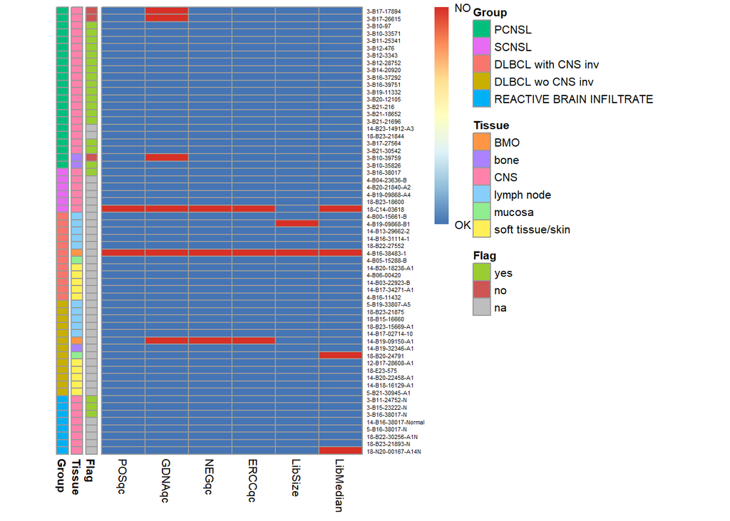